# 15 Introduction to charts

```r
# ETL
library(tidyverse)
```

# 16 Introduction

We have performed our ETL and now we have some tidy data, ready for the final step : **data visualization** (also called, in short, *“dataviz”*).

R has a very rich environment to create insightful visuals, whether they are charts or tables.

In this second toolbox, we will learn how to create some charts :

- introducing some beautiful and practical libraries, such as `highcharter`, `leaflet`, `networkD3`,…
- creating some classic charts : line chart, bar chart, pie chart.
  - mainly using the library `highcharter`.
- and studying some other useful ones, such has sankey or maps.

Then, in the third toolbox we will introduce other libraries for tables, with a particular focus on 2 packages : `reactable` and `reactablefmtr` .

Those 2 libraries, often combined with some functions (to create some particular html visuals) that we will present, allow to create some clear, beautiful and insightful tables.

We will see that very often the workflow to create charts or tables will be as below :

- **a 4 steps workflow :**
  - **step 1** : get data.
  - **step 2** : filter data.
  - **step 3** : transform data.
  - **step 4** : to create the visual, for example a chart or a table.
    - **note** : this last step could also be used to create a data frame, or a reactive object (more about this when we go through the part related to the creation of shiny web apps).
- The steps 1 to 3 aim to **generate a data frame which will be used to create several different charts or tables**.

This approach allows to keep our code simple :

- **limit the number of objects that we create**, especially if we create a data frame which will be used to create different charts or tables.
- **facilitate the maintenance or update of the codes.**
  - reusing the data frame generated during the first 3 steps.

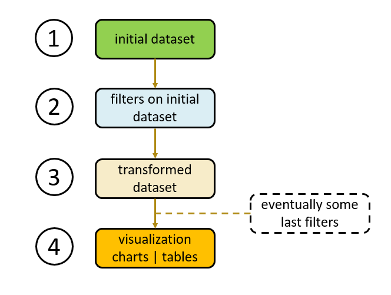

Figure 47 : classic work flow for data visualization

# 17 Data frame structure

## 17.1 2 variables

To create a very simple chart, for example a line chart or a bar chart, we need at least 2 variables :

- a dimension.
- a measure.

The dimension is usually the x axis. The measure is the y axis.

In order to create those charts, **we may have to transform the initial data frame to reach this format** **, where one variable is either a dimension or a measure.**

It’s the purpose of the steps 1 & 2 or 1 to 3 that we described above.

The figure below presents the most simple structure :

- just 2 variables.
- one dimension (the months of a year) and one measure (some sales quantities for example).

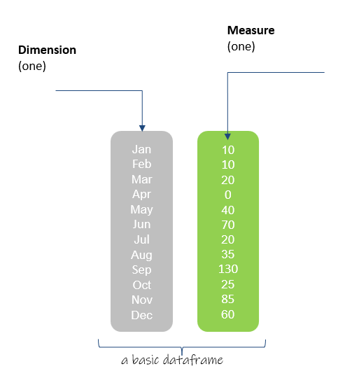

Figure 48 : data frame for a simple chart with 2 variables

## 17.2 Multi-variables structure

We also can have a data frame with more variables :

- several measures.
- or several dimensions.
- or several measures and dimensions.

Let’s look at the 2 following illustrations :

### 17.2.1 several measures

This data frame contains :

- **one dimension** : the months of a year.
- **3 variables of measures** : the (monthly) sales quantities of each calendar year.

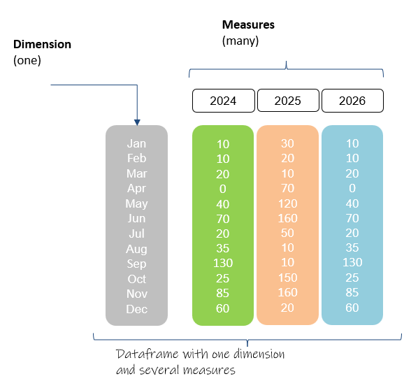

Figure 49 : data frame with several measures

### 17.2.2 several dimensions

We also could have :

- **several dimensions** : calendar year and the months of a year.
- **one measure** : the (monthly) sales quantities of each calendar year.

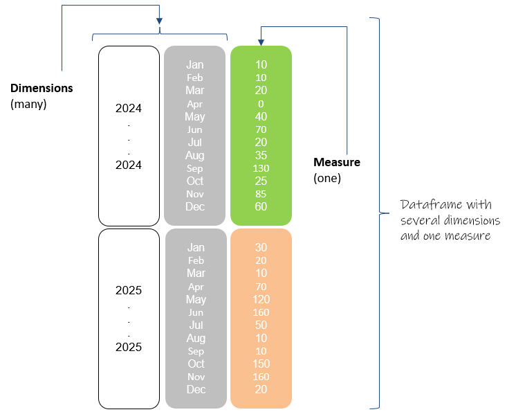

Figure 50 : data frame with several dimensions

# 18 Syntax to create a chart

The example below is related to the library `highcharter`. However, most of the libraries (`ggplot2`, `plotly`,…) have a very similar approach.

There are 3 parts, that you can write in a different order :

- **part 1** : the initial set up, it’s about the title / subtitle / theme / …
- **part 2** : the x axis.
- **part 3** : the y axis.

In the example below ([highcharter](https://jkunst.com/highcharter/)), we also see how to :

- **change a** **theme**, i.e. the **background of a chart**
  - for example : the economist, google, 538,…
- **affect a color to a serie**
  - for example, simply writing : steelblue, gold, mediumseagreen, salmon…
  - you can also use the RGB code or the HEX code of a color.

You can find all the color names, RGB or HEX codes on internet, for example for a green color : https://www.rapidtables.com/web/color/green-color.html

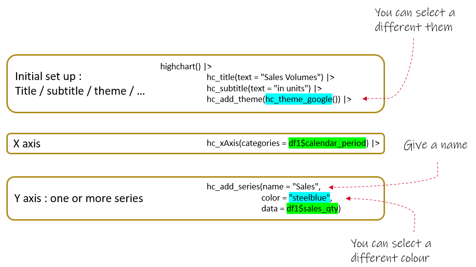

Figure 51 : syntax to create a line chart with highcharter

In the next section, we will see how to create some classic charts using the library `highcharter`.

# 19 R Color Brewer Package

Let’s introduce briefly here the R package `RColorBrewer`.

This package contains some **ready-to-use color palettes** for creating beautiful graphics.

- It’s very handy because we don’t have to define the colors of each serie.
- The colors will be affected automatically, based on the palette we choose.

You can learn more [here](https://www.datanovia.com/en/blog/the-a-z-of-rcolorbrewer-palette/) .

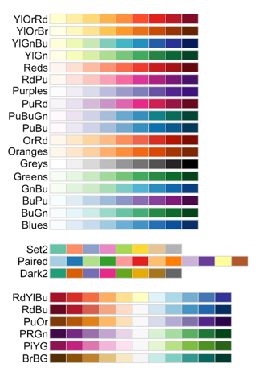

Figure 52 : some palettes available in Rcolorbrewer

We will use this package in the next examples.